# TCM Report

Anthony Morada

3/13/2020

# Daily Checkup and Deficient Services

```r
library(readxl)
master <- read_excel("~/Documents/safedata/tcm-quicc/master.xlsx", col_types = c("text", "text", "date", "text", "date", "date", "date", "text", "date", "date", "text", "text", "numeric", "text", "text", "text"))

monitor <- read_excel("~/Documents/safedata/tcm-quicc/monitor.xlsx", col_types = c("date", "numeric", "numeric", "numeric", "numeric", "numeric", "numeric", "numeric", "numeric", "numeric", "numeric"))

preint <- read_excel("~/Documents/safedata/tcm-quicc/preintervention.xls", col_types = c("text", "date", "date","text", "date", "date", "text", "text", "text", "numeric", "numeric", "date", "numeric", "numeric", "numeric", "numeric", "numeric", "text", "numeric","numeric", "text", "skip", "text"),skip = 2)

library(ggplot2)
```

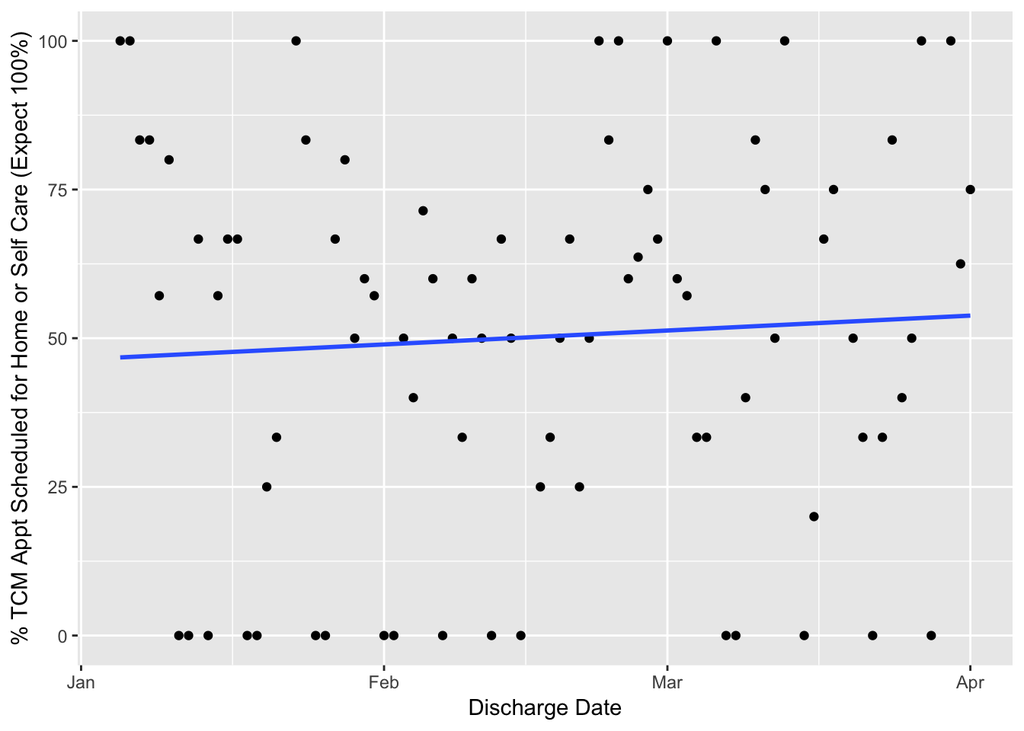

```r
ggplot(monitor, aes(`Discharge Date`, `% TCM Appt Scheduled for Home or Self Care (Expect 100%)`)) +
  geom_point() +
  geom_smooth(method = "lm", se = FALSE)
```

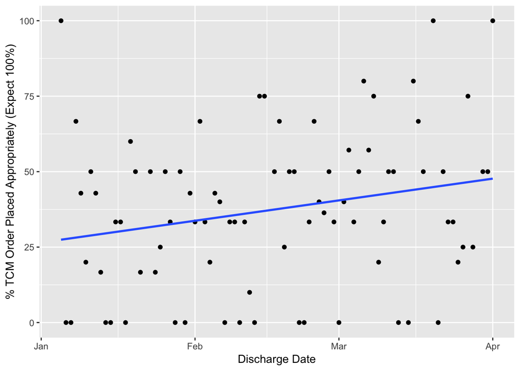

```r
ggplot(monitor, aes(`Discharge Date`, `% TCM Order Placed Appropriately (Expect 100%)`)) +
  geom_point() +
  geom_smooth(method = "lm", se = FALSE)
```

Follow the hashmarks for the information. TRUE == Has TCM Ordered for Home

```r
## Number of discharges
nrow(master)
```

```
## [1] 489
```

```r
## Number of people discharged home
sum(grepl("home", master$Disposition, ignore.case = T))
```

```
## [1] 376
```

```r
t <- master[grepl("home", master$Disposition, ignore.case = T),]
## Number of people with TCM Order
table(as.logical(t$`TCM Order`))
```

```
##
## FALSE  TRUE
##   235   141
```

```r
## Service and TCM Orders
table(t$`TCM Order`, t$Service)
```

```
##
##         CARDIOLOGY CRITICAL CARE MEDICAL FAMILY PRACTICE GENERAL SURGERY
##   FALSE          0                     1              11               1
##   TRUE           7                     0              26               0
##
##         HOSPITALIST INTERNAL MEDICINE NEPHROLOGY OTORHINOLARYNGOLOGY
##   FALSE         144                20          1                   1
##   TRUE           97                11          0                   0
##
##         PULMONARY TRAUMA VASCULAR SURGERY
##   FALSE         3     52                1
##   TRUE          0      0                0
```

```r
rm(t)
```

# Combining Preintervention Data with Followup Data

There is a date gap between the two data sets we have. Preintervention and the monitor data we have been following.

```r
## our followup dates
summary(master$Discharged)
```

```
##                  Min.               1st Qu.                Median
## "2020-01-05 00:00:00" "2020-01-24 00:00:00" "2020-02-12 16:58:00"
##                  Mean               3rd Qu.                  Max.
## "2020-02-14 06:48:08" "2020-03-04 19:01:00" "2020-04-01 16:42:00"
```

```r
## pre intervention dates
summary(preint$Discharged)
```

```
##                  Min.               1st Qu.                Median
## "2019-04-01 14:35:00" "2019-06-21 16:00:00" "2019-09-03 16:59:00"
##                  Mean               3rd Qu.                  Max.
## "2019-08-11 08:37:47" "2019-10-03 11:51:00" "2019-10-31 13:31:00"
```

Merging preintervention data to our master list.

```r
library(dplyr)
preint <- preint %>%
  select(MRN, `Admit Date`, `Discharge DX`, Discharged, `TCM Completed Date(Within 2`, `TCM Made Date`, `TCM Made By`, Disposition, Service, `ED Visits Past Year`, `PCP Dept`, `TCM With PCP?`)


# Also will have to add extra column for "Follow up With__ Order"
preint$`Follow up With__ Order` <- NA
preint$`TCM With PCP?` <- gsub("0", "FALSE", preint$`TCM With PCP?`)
preint$`TCM With PCP?` <- gsub("1", "TRUE", preint$`TCM With PCP?`)
preint$`TCM With PCP?` <- as.character(preint$`TCM With PCP?`)

# Columns to remove from the master: unit, TCM (Any Specialty), TCM Made Prior, Had to replace PCP Department with PCP (now this column will be a mix of PCPs and PCP department),
master <- master %>%
    select(-Unit, -`TCM (Any Specialty)`, -`TCM Made Prior Appt`)

# Merging the two tables together
colnames(preint) <- colnames(master)
final <- rbind(master,preint) #bind
final <- final[order(final$Discharged),]
final$Discharged <- as.Date(final$Discharged)
final <- final[!duplicated(final),]
library(openxlsx)
write.xlsx(final,"~/Documents/safedata/tcm-quicc/final.xlsx")
```

# Data Summary after Merging Preintervention with Monitor Data

```r
## Number of discharges
nrow(final)
```

```
## [1] 1194
```

```r
## Number of people discharged home
sum(grepl("home", final$Disposition, ignore.case = T))
```

```
## [1] 902
```

```r
t <- final[grepl("home", final$Disposition, ignore.case = T),]
## Number of people with TCM Order
table(as.logical(t$`TCM Order`))
```

```
##
## FALSE  TRUE
##   541   361
```

```r
## Service and TCM Orders
table(t$`TCM Order`, t$Service)
```

```
##
##         CARDIAC SURGERY CARDIOLOGY CRITICAL CARE MEDICAL FAMILY PRACTICE
##   FALSE               2          4                     1              37
##   TRUE                0         11                     0              33
##
##         GENERAL SURGERY HOSPITALIST INTERNAL MEDICINE NEPHROLOGY
##   FALSE               6         336                34          4
##   TRUE                4         257                21          0
##
##         ORTHOPEDIC OTORHINOLARYNGOLOGY PULMONARY TRAUMA VASCULAR SURGERY
##   FALSE          1                   1         4    108                3
##   TRUE           0                   0         2     31                2
```

```r
rm(t)
```

```r
#pulling in monitor-original for colnames
monitor_original <- read_excel("~/Documents/safedata/tcm-quicc/monitor-original.xlsx", col_types = c("date", "numeric", "numeric", "numeric", "numeric", "numeric", "numeric", "numeric", "numeric", "numeric", "numeric"))
monitor <- monitor_original[0,]
rm(monitor_original)
fill <- monitor

#loop for creating montior report

for (i in 1:length(unique(as.Date(final$Discharged)))) {
  fill[1,]<-NA
  fill$`Discharge Date` <- unique(as.Date(final$Discharged))[i]
  final$Discharged <- as.Date(final$Discharged)
  sub <- subset(final, final$Discharged == as.Date(fill$`Discharge Date`))

  fill$`Total discharges` <- nrow(sub)
  fill$`Total Discharge to home` <- sum(grepl("home", sub$Disposition, ignore.case = T))
  fill$`TCM Order for Home or Self Care Disposition` <- sum(sub$`TCM Order` == TRUE & grepl("home", sub$Disposition, ignore.case = T))
  fill$`% TCM Order Placed Appropriately (Expect 100%)` <- fill$`TCM Order for Home or Self Care Disposition`/fill$`Total Discharge to home` * 100
  fill$`Total TCM Appts made for home dischrg` <- sum(grepl("home", sub$Disposition, ignore.case = T) & !is.na(sub$`TCM Appt Date (Within 2 Weeks)`))
  fill$`% TCM Appt Scheduled for Home or Self Care (Expect 100%)` <- fill$`Total TCM Appts made for home dischrg`/fill$`Total Discharge to home` * 100
  fill$`Total TCM's Scheduled for SNF (Expect 0)` <- sum(!grepl("home", sub$Disposition, ignore.case = T) & sub$`TCM Order` == TRUE)

  # subset here for home patients only with TCM appointments
  sub <- sub[grepl("home", sub$Disposition, ignore.case = T) & !is.na(sub$`TCM Appt Date (Within 2 Weeks)`),]
  fill$`% scheduled within 7 days` <- sum(as.numeric(as.Date(sub$`TCM Appt Date (Within 2 Weeks)`)-as.Date(sub$Discharged)) <= 7)/fill$`Total TCM Appts made for home dischrg` * 100
  fill$`% scheduled iwthin 8-14 days` <- sum(as.Date(sub$`TCM Appt Date (Within 2 Weeks)`)-as.Date(sub$Discharged) <= 14 & as.Date(sub$`TCM Appt Date (Within 2 Weeks)`)-as.Date(sub$Discharged) > 7)/fill$`Total TCM Appts made for home dischrg` * 100
  fill$`%scheduled within 14 days` <- sum(as.Date(sub$`TCM Appt Date (Within 2 Weeks)`)-as.Date(sub$Discharged) <= 14)/fill$`Total TCM Appts made for home dischrg` * 100

  #rbinding to monitor
  monitor <- rbind(monitor,fill)
  monitor <- monitor[!duplicated(monitor),]
  }

rm(i)
rm(sub)
rm(fill)

write.xlsx(monitor,"~/Documents/safedata/tcm-quicc/monitor.xlsx")
```

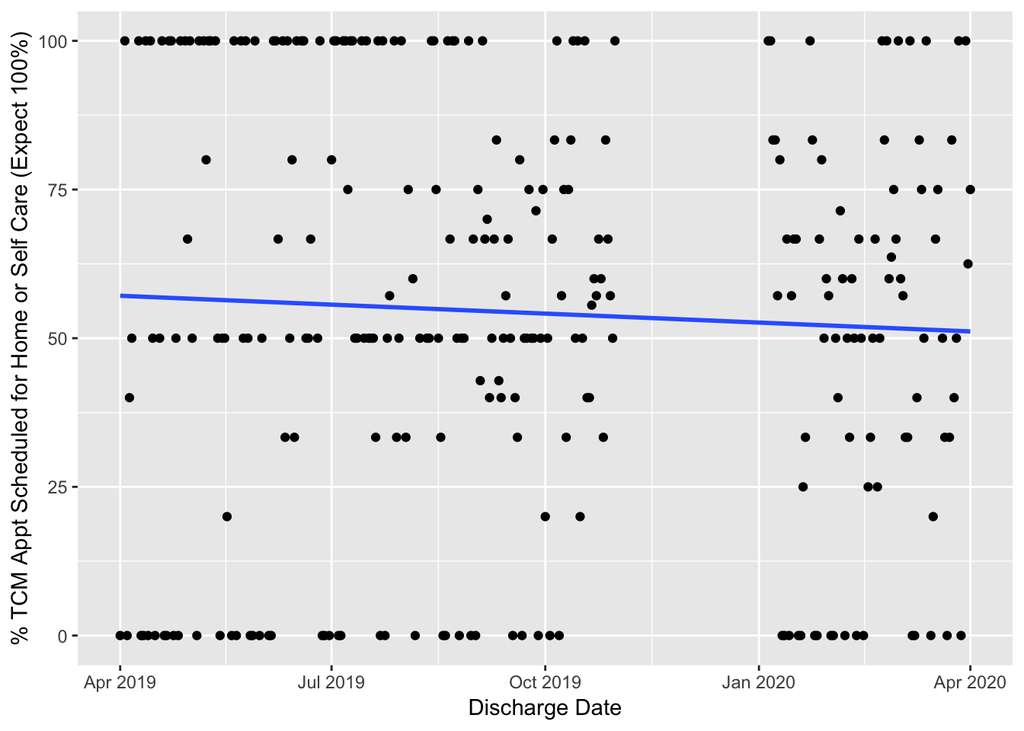

```r
ggplot(monitor, aes(`Discharge Date`, `% TCM Appt Scheduled for Home or Self Care (Expect 100%)`)) +
  geom_point() +
  geom_smooth(method = "lm", se = FALSE)
```

```r
ggsave("~/Documents/safedata/tcm-quicc/TCM-apt-schedule.pdf")
```

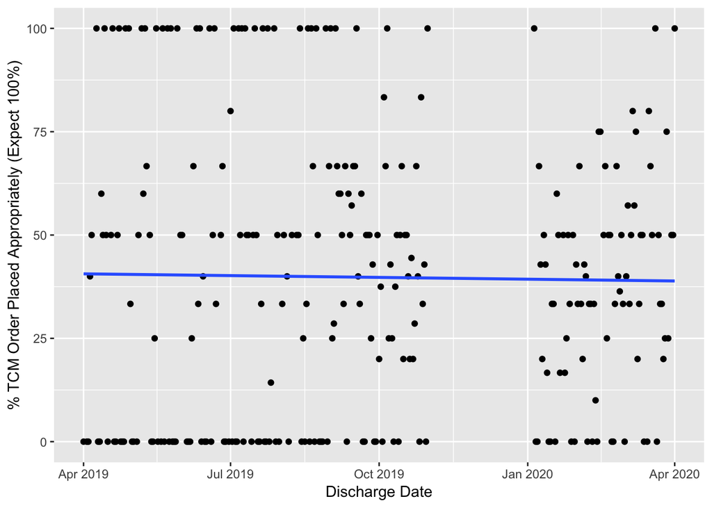

```r
ggplot(monitor, aes(`Discharge Date`, `% TCM Order Placed Appropriately (Expect 100%)`)) +
  geom_point() +
  geom_smooth(method = "lm", se = FALSE)
```

```r
ggsave("~/Documents/safedata/tcm-quicc/TCM-ord-placed.pdf")
```

# Data Analysis

Date of Intervention: Jan 28th 2020

```r
pre <- final[final$Discharged < "2020-01-28",]
post <- final[final$Discharged >= "2020-01-28",]
```

## Pre intervention data summary

```r
# number of discharges
nrow(pre)
```

```
## [1] 848
```

```r
# number of patients
length(unique(pre$MRN))
```

```
## [1] 787
```

```r
# date range
summary(pre$Discharged)
```

```
##         Min.      1st Qu.       Median         Mean      3rd Qu.
## "2019-04-01" "2019-07-08" "2019-09-13" "2019-09-06" "2019-10-21"
##         Max.
## "2020-01-27"
```

```r
# Patient disposition
summary(as.factor(pre$Disposition))
```

```
##   Discharged/Transferred to an inpatient rehab facility (IFC)
##                                                            20
## Discharged/Transferred to another short term general hospital
##                                                             5
##              Discharged/Transferred to home under care of HHC
##                                                            66
##             Discharged/Transferred to long term care hospital
##                                                             1
##                                 Discharged/Transferred to SNF
##                                                           167
##                                                       Expired
##                                                             9
##                                   Home or Self Care (Routine)
##                                                           557
##                                                Hospice - Home
##                                                             7
##                                    Hospice - Medical Facility
##                                                             3
##                                   Left against medical advice
##                                                            11
##                                                     Swing Bed
##                                                             2
```

```r
# Number of patients to home. TRUE = Home
summary(grepl("home", pre$Disposition, ignore.case = TRUE))
```

```
##    Mode   FALSE    TRUE
## logical     218     630
```

```r
# Number of discharges with an associated TCM appointment within 2 weeks
summary(!is.na(pre$`TCM Appt Date (Within 2 Weeks)`))
```

```
##    Mode   FALSE    TRUE
## logical     469     379
```

```r
# Number of patients with a discharge of "home" AND a TCM Appointment
summary(grepl("home", pre$Disposition, ignore.case = TRUE) & !is.na(pre$`TCM Appt Date (Within 2 Weeks)`))
```

```
##    Mode   FALSE    TRUE
## logical     490     358
```

```r
# Number of TCM Orders
summary(as.factor(pre$`TCM Order`))
```

```
## FALSE  TRUE
##   582   266
```

```r
# Number of TCM Order AND TCM appointment within 2 weeks
summary(!is.na(pre$`TCM Appt Date (Within 2 Weeks)`) & pre$`TCM Order` == "TRUE")
```

```
##    Mode   FALSE    TRUE
## logical     632     216
```

```r
# Number of TCM Order AND TCM appointment within 2 weeks AND discharge "home"
summary(grepl("home", pre$Disposition, ignore.case = TRUE) & !is.na(pre$`TCM Appt Date (Within 2 Weeks)`) & pre$`TCM Order` == "TRUE")
```

```
##    Mode   FALSE    TRUE
## logical     636     212
```

## Post intervention data summary

```r
# number of discharges
nrow(post)
```

```
## [1] 346
```

```r
# number of patients
length(unique(post$MRN))
```

```
## [1] 327
```

```r
# date range
summary(post$Discharged)
```

```
##         Min.      1st Qu.       Median         Mean      3rd Qu.
## "2020-01-28" "2020-02-11" "2020-02-26" "2020-02-26" "2020-03-10"
##         Max.
## "2020-04-01"
```

```r
# Patient disposition
summary(as.factor(post$Disposition))
```

```
##   Discharged/Transferred to an inpatient rehab facility (IFC)
##                                                            16
## Discharged/Transferred to another short term general hospital
##                                                             4
##               Discharged/Transferred to Court/Law Enforcement
##                                                             1
##              Discharged/Transferred to home under care of HHC
##                                                            18
##                                 Discharged/Transferred to SNF
##                                                            44
##                                   Home or Self Care (Routine)
##                                                           254
##                                   Left against medical advice
##                                                             9
```

```r
# Number of patients to home. TRUE = Home
summary(grepl("home", post$Disposition, ignore.case = TRUE))
```

```
##    Mode   FALSE    TRUE
## logical      74     272
```

```r
# Number of discharges with an associated TCM appointment within 2 weeks
summary(!is.na(post$`TCM Appt Date (Within 2 Weeks)`))
```

```
##    Mode   FALSE    TRUE
## logical     198     148
```

```r
# Number of patients with a discharge of "home" AND a TCM Appointment
summary(grepl("home", post$Disposition, ignore.case = TRUE) & !is.na(post$`TCM Appt Date (Within 2 Weeks)`))
```

```
##    Mode   FALSE    TRUE
## logical     208     138
```

```r
# Number of TCM Orders
summary(as.factor(post$`TCM Order`))
```

```
## FALSE  TRUE
##   222   124
```

```r
# Number of TCM Order AND TCM appointment within 2 weeks
summary(!is.na(post$`TCM Appt Date (Within 2 Weeks)`) & post$`TCM Order` == "TRUE")
```

```
##    Mode   FALSE    TRUE
## logical     278      68
```

```r
# Number of TCM Order AND TCM appointment within 2 weeks AND discharge "home"
summary(grepl("home", post$Disposition, ignore.case = TRUE) & !is.na(post$`TCM Appt Date (Within 2 Weeks)`) & post$`TCM Order` == "TRUE")
```

```
##    Mode   FALSE    TRUE
## logical     281      65
```

## Data Comparison

### Question 1

Q1: For patients being discharged home, did our intervention improve TCM orders and/or TCM appointments?

The denominator will be patients discharged home because we are comparing the proportion of TCM appointments and/or orders for patients who are going home.

#### Comparing TCM Appointments made for patients going Home. Pre vs Post intervention

```r
# Patients discharged to "Home"
sum(grepl("home", final$Disposition, ignore.case = TRUE))
```

```
## [1] 902
```

```r
# Patients discharged to "Home" in pre
sum(grepl("home", pre$Disposition, ignore.case = TRUE))
```

```
## [1] 630
```

```r
# Patients discharged to "Home" in post
sum(grepl("home", post$Disposition, ignore.case = TRUE))
```

```
## [1] 272
```

```r
# Patients to discharged to "Home" with TCM Appt within 2 week. TRUE = has TCM appt
summary(!is.na(final[grepl("home", final$Disposition, ignore.case = TRUE),]$`TCM Appt Date (Within 2 Weeks)`))
```

```
##    Mode   FALSE    TRUE
## logical     406     496
```

```r
table(final[grepl("home", final$Disposition, ignore.case = TRUE),]$Discharged < "2020-01-28", !is.na(final[grepl("home", final$Disposition, ignore.case = TRUE),]$`TCM Appt Date (Within 2 Weeks)`))
```

```
##
##         FALSE TRUE
##   FALSE   134  138
##   TRUE    272  358
```

```r
chisq.test(table(final[grepl("home", final$Disposition, ignore.case = TRUE),]$Discharged < "2020-01-28", !is.na(final[grepl("home", final$Disposition, ignore.case = TRUE),]$`TCM Appt Date (Within 2 Weeks)`)))
```

```
##
##  Pearson's Chi-squared test with Yates' continuity correction
##
## data:  table(final[grepl("home", final$Disposition, ignore.case = TRUE),     ]$Discharged < "2020-01-28", !is.na(final[grepl("home", final$Disposition,     ignore.case = TRUE), ]$`TCM Appt Date (Within 2 Weeks)`))
## X-squared = 2.6061, df = 1, p-value = 0.1065
```

#### Comparing TCM Orders made for patients going Home. Pre vs Post intervention

```r
# Patients discharged to "Home"
sum(grepl("home", final$Disposition, ignore.case = TRUE))
```

```
## [1] 902
```

```r
# Patients discharged to "Home" in pre
sum(grepl("home", pre$Disposition, ignore.case = TRUE))
```

```
## [1] 630
```

```r
# Patients discharged to "Home" in post
sum(grepl("home", post$Disposition, ignore.case = TRUE))
```

```
## [1] 272
```

```r
# Patients to discharged to "Home" with TCM order. TRUE = has TCM order
summary(as.logical(final[grepl("home", final$Disposition, ignore.case = TRUE),]$`TCM Order`))
```

```
##    Mode   FALSE    TRUE
## logical     541     361
```

```r
table(final[grepl("home", final$Disposition, ignore.case = TRUE),]$Discharged < "2020-01-28", as.logical(final[grepl("home", final$Disposition, ignore.case = TRUE),]$`TCM Order`))
```

```
##
##         FALSE TRUE
##   FALSE   162  110
##   TRUE    379  251
```

```r
chisq.test(table(final[grepl("home", final$Disposition, ignore.case = TRUE),]$Discharged < "2020-01-28", as.logical(final[grepl("home", final$Disposition, ignore.case = TRUE),]$`TCM Order`))
)
```

```
##
##  Pearson's Chi-squared test with Yates' continuity correction
##
## data:  table(final[grepl("home", final$Disposition, ignore.case = TRUE),     ]$Discharged < "2020-01-28", as.logical(final[grepl("home",     final$Disposition, ignore.case = TRUE), ]$`TCM Order`))
## X-squared = 0.0089731, df = 1, p-value = 0.9245
```

### Question 2

Q2: For patients not discharged home, did our interventin improve appropriate TCM orders and/or TCM appointments? (ie. Patients discharged to SNF or Short term rehab should not have TCM orders/appts)

#### Comparing TCM Appointments made for patients not going Home. Pre vs Post intervention

```r
# Patients discharged other than Home
sum(!grepl("home", final$Disposition, ignore.case = TRUE))
```

```
## [1] 292
```

```r
# Patients discharged other than Home in Pre
sum(!grepl("home", pre$Disposition, ignore.case = TRUE))
```

```
## [1] 218
```

```r
# Patients discharged other than Home in Post
sum(!grepl("home", post$Disposition, ignore.case = TRUE))
```

```
## [1] 74
```

```r
# Patients to discharged other than Home with TCM Appt within 2 week. TRUE = has TCM appt
summary(!is.na(final[!grepl("home", final$Disposition, ignore.case = TRUE),]$`TCM Appt Date (Within 2 Weeks)`))
```

```
##    Mode   FALSE    TRUE
## logical     261      31
```

```r
table(final[!grepl("home", final$Disposition, ignore.case = TRUE),]$Discharged < "2020-01-28", !is.na(final[!grepl("home", final$Disposition, ignore.case = TRUE),]$`TCM Appt Date (Within 2 Weeks)`))
```

```
##
##         FALSE TRUE
##   FALSE    64   10
##   TRUE    197   21
```

```r
chisq.test(table(final[!grepl("home", final$Disposition, ignore.case = TRUE),]$Discharged < "2020-01-28", !is.na(final[!grepl("home", final$Disposition, ignore.case = TRUE),]$`TCM Appt Date (Within 2 Weeks)`)))
```

```
##
##  Pearson's Chi-squared test with Yates' continuity correction
##
## data:  table(final[!grepl("home", final$Disposition, ignore.case = TRUE),     ]$Discharged < "2020-01-28", !is.na(final[!grepl("home",     final$Disposition, ignore.case = TRUE), ]$`TCM Appt Date (Within 2 Weeks)`))
## X-squared = 0.51544, df = 1, p-value = 0.4728
```

#### Comparing TCM Orders made for patients not going Home. Pre vs Post intervention

```r
# Patients discharged other than Home
sum(!grepl("home", final$Disposition, ignore.case = TRUE))
```

```
## [1] 292
```

```r
# Patients discharged other than Home in Pre
sum(!grepl("home", pre$Disposition, ignore.case = TRUE))
```

```
## [1] 218
```

```r
# Patients discharged other than Home in Post
sum(!grepl("home", post$Disposition, ignore.case = TRUE))
```

```
## [1] 74
```

```r
# Patients to discharged other than Home with TCM order. TRUE = has TCM order
summary(as.logical(final[!grepl("home", final$Disposition, ignore.case = TRUE),]$`TCM Order`))
```

```
##    Mode   FALSE    TRUE
## logical     263      29
```

```r
table(final[!grepl("home", final$Disposition, ignore.case = TRUE),]$Discharged < "2020-01-28", as.logical(final[!grepl("home", final$Disposition, ignore.case = TRUE),]$`TCM Order`))
```

```
##
##         FALSE TRUE
##   FALSE    60   14
##   TRUE    203   15
```

```r
chisq.test(table(final[!grepl("home", final$Disposition, ignore.case = TRUE),]$Discharged < "2020-01-28", as.logical(final[!grepl("home", final$Disposition, ignore.case = TRUE),]$`TCM Order`)))
```

```
##
##  Pearson's Chi-squared test with Yates' continuity correction
##
## data:  table(final[!grepl("home", final$Disposition, ignore.case = TRUE),     ]$Discharged < "2020-01-28", as.logical(final[!grepl("home",     final$Disposition, ignore.case = TRUE), ]$`TCM Order`))
## X-squared = 7.6551, df = 1, p-value = 0.005661
```

| Variable | n |
| --- | --- |
| Total Number Discharges | 1194 |
| Number of Patients | 1086 |
| Discharged to Home | 902 |
| Discharged other than Home | 292 |

# Medians

```r
# Summary of overall monitor data
summary(monitor$`% TCM Appt Scheduled for Home or Self Care (Expect 100%)`, na.rm = T)
```

```
##    Min. 1st Qu.  Median    Mean 3rd Qu.    Max.    NA's
##    0.00   33.33   50.00   54.25   83.33  100.00      13
```

```r
sd(monitor$`% TCM Appt Scheduled for Home or Self Care (Expect 100%)`, na.rm = T)
```

```
## [1] 34.73478
```

```r
# Summary of pre
summary(monitor[monitor$`Discharge Date` < "2020-01-28",]$`% TCM Appt Scheduled for Home or Self Care (Expect 100%)`, na.rm = T)
```

```
##    Min. 1st Qu.  Median    Mean 3rd Qu.    Max.    NA's
##    0.00   33.33   50.00   55.26  100.00  100.00      13
```

```r
sd(monitor[monitor$`Discharge Date` < "2020-01-28",]$`% TCM Appt Scheduled for Home or Self Care (Expect 100%)`, na.rm = T)
```

```
## [1] 35.87516
```

```r
# Summary of post
summary(monitor[monitor$`Discharge Date` >= "2020-01-28",]$`% TCM Appt Scheduled for Home or Self Care (Expect 100%)`, na.rm = T)
```

```
##    Min. 1st Qu.  Median    Mean 3rd Qu.    Max.
##    0.00   33.33   50.00   50.80   71.43  100.00
```

```r
sd(monitor[monitor$`Discharge Date` >= "2020-01-28",]$`% TCM Appt Scheduled for Home or Self Care (Expect 100%)`, na.rm = T)
```

```
## [1] 30.50299
```